# cctv 설치 대수와 예방률, 검거율과의 상관관계.

60140275 장민지, 60130897 장일구

2018년 11월 2일

## 데이터에 흥미를 가지게 된 이유

[figure not shown]

2015년 국민안전처와 경찰청이 CCTV 설치 구역에 5대 강력범죄가 26.6% 감소했다는 발표가 있었다. 2014년, 강북구는 방범용 cctv 설치 후에 범죄 발생률이 급감했다고 보도한 반면 , 2018년 강남구는 cctv 설치 대수가 1위임에도 불구하고 범죄 발생률이 높은 것으로 드러났다. 평균은 감소하였으나, 지역별 특성에 따라 효과가 미치는 정도가 판이함을 확인하였다. 따라서 데이터를 구체적으로 살펴보아 첫째, 범죄 예방에 cctv가 효과가 있는지를 확인하고, 둘째, 이 차이를 결정하는 변수는 무엇이 있는지를 확인해보고자 하였다.

[cctv 설치로 범죄율 27% 감소](https://blog.naver.com/tsisolution/220556594693) [강북구, 방범용 CCTV 설치 뒤 범죄발생 급감](http://biz.heraldcorp.com/view.php?ud=20140402000092) [권미혁 “강남구 CCTV 설치수량 최대…정작 성범죄 발생은 1위”](https://news.naver.com/main/read.nhn?mode=LSD&mid=sec&oid=003&aid=0008862271&sid1=001)

## 데이터와 관련된 배경 이론

- 상황적 범죄예방(Situational Crime Prevention)이론, Ronald Clarke

Ronald Clarke은 4가지 범죄기회제거기법을 제시한 후 이를 다시 16가지 세부 기법으로 구체화하였다. 방범용 CCTV는 범죄발각에 대한 위험증가이며 특히, **공식적 감시(Formal Surveillance)**에 핵심을 두고 있다. 즉 방범용 CCTV는 감시의 강화를 통해 범죄 실패의 리스크(Risk)를 증가시킴으로써 궁극적으로 범죄자로 하여금 범죄 실행의 욕구를 경감시키는 전략으로 볼 수 있다.

- 일상활동이론(Routine Activity Theory), Cohen and Felson(1979)

일상활동이론에서 범죄발생은 “ 범죄 실행의지가 있는 범죄자(Motivated Offenders)”, “적당한 대상(Suitable Targets)”, “예방능력이 있는 보호자의 부재(Absence of Capable Guardian)” 라는 세 가지 조건이 함께 만났을 때 이루어지며 또한 범죄성공가능성 역시 높아진다고 하였다(Cohen and Felson, 1979). 방범용 CCTV가 보호자 역할을 하여 잠재적 범죄자가 자신이 **감시**당하고 있다는 것을 인지할 경우, 발각의 두려움으로 인하여 범죄 실행의지를 억제하게 되고 궁극적으로 범죄가 예방되는 것이다.

[방범용 CCTV의 범죄유형별 범죄예방효과 연구](http://dcollection.cau.ac.kr/common/orgView/000000196849)

## 데이터와 관련한 가설

*가설1. CCTV의 한시적 효과가 있다.

*가설2. 범죄상황이론은 범죄는 주변 환경에 의해 유인 혹은 억제가 가능하고, 그러한 환경 요인을 밝혀내는데 중점을 둔다.

*가설3. CCTV 설치 지역이 유흥가 위주이다. 즉, 환경에 의한 우발적 범죄의 가능성을 전부 포함한다.

## 사용 데이터

[서울 열린 데이터광장,2017](http://data.seoul.go.kr/)

## 데이터 불러들이기

```r
library(readxl)
library(dplyr)
```

```r
library(ggplot2)
crime_raw<- read.csv("crime.csv")
cctv_raw <- read.csv("cctv.csv")
cr <- crime_raw
cc <- cctv_raw
```

## 데이터 살펴보기

```r
summary(cr)
```

```
##    기간        자치구        합계        합계.1        살인       살인.1
##  2017:26   강남구 : 1   1,999  : 1   1,652  : 1   1      :5   1      : 4
##  기간: 1   강동구 : 1   107,835: 1   2,031  : 1   7      :4   5      : 3
##            강북구 : 1   2,767  : 1   2,242  : 1   5      :3   6      : 3
##            강서구 : 1   3,113  : 1   2,299  : 1   6      :3   7      : 3
##            관악구 : 1   3,265  : 1   2,479  : 1   11     :2   10     : 2
##            광진구 : 1   3,330  : 1   2,572  : 1   3      :2   4      : 2
##            (Other):21   (Other):21   (Other):21   (Other):8   (Other):10
##       강도       강도.1   강간강제추행 강간강제추행.1      절도
##  3      :5   5      :4   172    : 2    149    : 2     1,014  : 1
##  5      :3   3      :3   104    : 1    181    : 2     1,072  : 1
##  7      :3   4      :3   132    : 1    1,412  : 1     1,141  : 1
##  8      :3   6      :3   138    : 1    106    : 1     1,226  : 1
##  1      :2   8      :3   165    : 1    115    : 1     1,230  : 1
##  10     :2   2      :2   173    : 1    122    : 1     1,344  : 1
##  (Other):9   (Other):9   (Other):20    (Other):19     (Other):21
##      절도.1        폭력        폭력.1
##  1,017  : 1   1,258  : 1   1,116  : 1
##  1,026  : 1   1,559  : 1   1,378  : 1
##  1,108  : 1   1,676  : 1   1,393  : 1
##  1,113  : 1   1,700  : 1   1,466  : 1
##  1,152  : 1   1,874  : 1   1,627  : 1
##  1,168  : 1   1,902  : 1   1,676  : 1
##  (Other):21   (Other):21   (Other):21
```

```r
str(cr)
```

```
## 'data.frame':    27 obs. of  14 variables:
##  $ 기간          : Factor w/ 2 levels "2017","기간": 2 1 1 1 1 1 1 1 1 1 ...
##  $ 자치구        : Factor w/ 27 levels "강남구","강동구",..: 23 27 24 25 21 16 6 11 26 17 ...
##  $ 합계          : Factor w/ 27 levels "1,999","107,835",..: 27 2 12 14 13 3 18 11 17 8 ...
##  $ 합계.1        : Factor w/ 27 levels "1,652","2,031",..: 27 26 24 9 10 2 16 15 17 5 ...
##  $ 살인          : Factor w/ 12 levels "1","11","142",..: 12 3 9 1 1 1 8 2 7 9 ...
##  $ 살인.1        : Factor w/ 15 levels "-","1","10","11",..: 15 6 14 1 2 2 10 3 10 12 ...
##  $ 강도          : Factor w/ 12 levels "1","10","13",..: 12 4 2 11 8 6 3 6 6 10 ...
##  $ 강도.1        : Factor w/ 13 levels "12","15","170",..: 13 3 2 12 7 6 11 8 7 11 ...
##  $ 강간강제추행  : Factor w/ 26 levels "104","132","138",..: 26 24 12 14 17 2 13 4 5 6 ...
##  $ 강간강제추행.1: Factor w/ 25 levels "1,412","106",..: 25 24 1 7 20 2 13 7 6 5 ...
##  $ 절도          : Factor w/ 27 levels "1,014","1,072",..: 27 25 13 17 7 2 21 11 9 6 ...
##  $ 절도.1        : Factor w/ 27 levels "1,017","1,026",..: 27 8 24 23 12 10 6 1 19 15 ...
##  $ 폭력          : Factor w/ 27 levels "1,258","1,559",..: 27 26 8 7 14 2 9 12 20 6 ...
##  $ 폭력.1        : Factor w/ 27 levels "1,116","1,378",..: 27 26 14 8 10 2 9 13 20 5 ...
```

```r
head(cr,10)
```

```
##    기간   자치구    합계 합계.1 살인 살인.1 강도 강도.1 강간강제추행
## 1  기간   자치구    발생   검거 발생   검거 발생   검거         발생
## 2  2017     합계 107,835 79,865  142    140  169    170        6,963
## 3  2017   종로구   4,057  4,437    7      9   10     15          253
## 4  2017     중구   4,184  2,851    1      -    9      9          267
## 5  2017   용산구   4,060  2,936    1      1    5      4          327
## 6  2017   성동구   2,767  2,031    1      1    3      3          132
## 7  2017   광진구   4,646  3,289    6      5   13      8          261
## 8  2017 동대문구   3,975  3,274   11     10    3      5          165
## 9  2017   중랑구   4,571  3,392    5      5    3      4          172
## 10 2017   성북구   3,434  2,479    7      7    8      8          173
##    강간강제추행.1   절도 절도.1   폭력 폭력.1
## 1            검거   발생   검거   발생   검거
## 2           6,558 41,162 21,421 59,399 51,576
## 3           1,412  1,644    905  2,143  2,096
## 4             149  1,846    889  2,061  1,804
## 5             289  1,346    626  2,381  2,016
## 6             106  1,072    543  1,559  1,378
## 7             208  2,220  1,168  2,146  1,900
## 8             149  1,547  1,017  2,249  2,093
## 9             144  1,533    813  2,858  2,426
## 10            134  1,344    703  1,902  1,627
```

```r
summary(cc)
```

```
##      기관명        소계          방범용       도시공원..놀이터
##  강남구 : 1   Min.   : 825   Min.   : 260.0   Min.   : 51.0
##  강동구 : 1   1st Qu.:1010   1st Qu.: 532.0   1st Qu.: 73.0
##  강북구 : 1   Median :1327   Median : 676.0   Median : 88.0
##  강서구 : 1   Mean   :1515   Mean   : 803.9   Mean   :116.5
##  관악구 : 1   3rd Qu.:1884   3rd Qu.: 974.0   3rd Qu.:139.0
##  광진구 : 1   Max.   :3238   Max.   :2076.0   Max.   :294.0
##  (Other):19
##   어린이.보호    쓰레기.무단투기       기타
##  Min.   : 20.0   Min.   :  0.00   Min.   : 27.0
##  1st Qu.:122.0   1st Qu.:  3.00   1st Qu.:237.0
##  Median :188.0   Median : 28.00   Median :333.0
##  Mean   :225.9   Mean   : 32.84   Mean   :336.2
##  3rd Qu.:305.0   3rd Qu.: 47.00   3rd Qu.:448.0
##  Max.   :722.0   Max.   :115.00   Max.   :617.0
##
```

```r
str(cc)
```

```
## 'data.frame':    25 obs. of  7 variables:
##  $ 기관명          : Factor w/ 25 levels "강남구","강동구",..: 1 2 3 4 5 6 7 8 9 10 ...
##  $ 소계            : int  3238 1010 831 911 2109 878 1884 1348 1566 825 ...
##  $ 방범용          : int  2076 537 469 623 1083 376 823 676 753 260 ...
##  $ 도시공원..놀이터: int  261 84 86 51 161 51 294 119 192 89 ...
##  $ 어린이.보호     : int  443 125 108 182 195 208 415 188 205 89 ...
##  $ 쓰레기.무단투기 : int  0 27 85 28 57 72 29 32 115 47 ...
##  $ 기타            : int  458 237 83 27 613 171 323 333 301 340 ...
```

```r
head(cc,10)
```

```
##    기관명 소계 방범용 도시공원..놀이터 어린이.보호 쓰레기.무단투기 기타
## 1  강남구 3238   2076              261         443               0  458
## 2  강동구 1010    537               84         125              27  237
## 3  강북구  831    469               86         108              85   83
## 4  강서구  911    623               51         182              28   27
## 5  관악구 2109   1083              161         195              57  613
## 6  광진구  878    376               51         208              72  171
## 7  구로구 1884    823              294         415              29  323
## 8  금천구 1348    676              119         188              32  333
## 9  노원구 1566    753              192         205             115  301
## 10 도봉구  825    260               89          89              47  340
```

```r
tail(cc)
```

```
##      기관명 소계 방범용 도시공원..놀이터 어린이.보호 쓰레기.무단투기 기타
## 20 영등포구 1277    653               91         122              38  373
## 21   용산구 2096   1336              113         168               7  472
## 22   은평구 2108   1147              196         527               3  235
## 23   종로구 1619    891               73          38               0  617
## 24     중구 1023    495               96          20              60  352
## 25   중랑구  916    532               74          54               0  256
```

- CCTV가 이미 발생한 범죄자를 추적하는것에는 매우 효과적이라는 것은 모두가 인정하는 부분이지만 범죄를 예방하는데에도 큰 효과가 있는지 알아보려한다. 각 구별 범죄발생 횟수와 CCTV설치 댓수 자료를 사용한다.

```r
cc <- rename(cc,자치구=기관명)
cc
```

```
##      자치구 소계 방범용 도시공원..놀이터 어린이.보호 쓰레기.무단투기 기타
## 1    강남구 3238   2076              261         443               0  458
## 2    강동구 1010    537               84         125              27  237
## 3    강북구  831    469               86         108              85   83
## 4    강서구  911    623               51         182              28   27
## 5    관악구 2109   1083              161         195              57  613
## 6    광진구  878    376               51         208              72  171
## 7    구로구 1884    823              294         415              29  323
## 8    금천구 1348    676              119         188              32  333
## 9    노원구 1566    753              192         205             115  301
## 10   도봉구  825    260               89          89              47  340
## 11 동대문구 1870    948               71         247              28  576
## 12   동작구 1302    693               88         291              19  211
## 13   마포구  980    387               86         101               0  406
## 14 서대문구 1254    603              230         129               0  292
## 15   서초구 2297   1552               62         316               0  367
## 16   성동구 1327    663               56         305              38  265
## 17   성북구 1651    974               72         320              98  187
## 18   송파구 1081    331              139         129              19  463
## 19   양천구 2482   1216               77         722              19  448
## 20 영등포구 1277    653               91         122              38  373
## 21   용산구 2096   1336              113         168               7  472
## 22   은평구 2108   1147              196         527               3  235
## 23   종로구 1619    891               73          38               0  617
## 24     중구 1023    495               96          20              60  352
## 25   중랑구  916    532               74          54               0  256
```

```r
df <- left_join(cc,cr, by = "자치구")
df <- rename(df,범죄발생 = 합계, 전체cctv = 소계,방범용cctv = 방범용,범죄검거 = 합계.1)
```

-factor형태 , 제거 및 numeric으로 전환

```r
df$범죄발생 <- sub(",","",df$범죄발생)
df$범죄발생<- as.numeric(df$범죄발생)


df$범죄검거 <- sub(",","",df$범죄검거)
df$범죄검거<- as.numeric(df$범죄검거)


df$살인 <- sub(",","",df$살인)
df$살인<- as.numeric(df$살인)

df$살인.1 <- sub(",","",df$살인.1)
df$살인.1<- as.numeric(df$살인.1)
df$강도 <- sub(",","",df$강도)
df$강도<- as.numeric(df$강도)

df$강도.1 <- sub(",","",df$강도.1)
df$강도.1<- as.numeric(df$강도.1)

df$강간강제추행 <- sub(",","",df$강간강제추행)
df$강간강제추행<- as.numeric(df$강간강제추행)


df$강간강제추행.1 <- sub(",","",df$강간강제추행.1)
df$강간강제추행.1<- as.numeric(df$강간강제추행.1)

df$절도 <- sub(",","",df$절도)
df$절도<- as.numeric(df$절도)


df$절도.1 <- sub(",","",df$절도.1)
df$절도.1<- as.numeric(df$절도.1)

df$폭력 <- sub(",","",df$폭력)
df$폭력<- as.numeric(df$폭력)


df$폭력.1 <- sub(",","",df$폭력.1)
df$폭력.1<- as.numeric(df$폭력.1)

summary(df)
```

```
##     자치구             전체cctv      방범용cctv     도시공원..놀이터
##  Length:25          Min.   : 825   Min.   : 260.0   Min.   : 51.0
##  Class :character   1st Qu.:1010   1st Qu.: 532.0   1st Qu.: 73.0
##  Mode  :character   Median :1327   Median : 676.0   Median : 88.0
##                     Mean   :1515   Mean   : 803.9   Mean   :116.5
##                     3rd Qu.:1884   3rd Qu.: 974.0   3rd Qu.:139.0
##                     Max.   :3238   Max.   :2076.0   Max.   :294.0
##
##   어린이.보호    쓰레기.무단투기       기타         기간       범죄발생
##  Min.   : 20.0   Min.   :  0.00   Min.   : 27.0   2017:25   Min.   :1999
##  1st Qu.:122.0   1st Qu.:  3.00   1st Qu.:237.0   기간: 0   1st Qu.:3434
##  Median :188.0   Median : 28.00   Median :333.0             Median :4184
##  Mean   :225.9   Mean   : 32.84   Mean   :336.2             Mean   :4313
##  3rd Qu.:305.0   3rd Qu.: 47.00   3rd Qu.:448.0             3rd Qu.:4895
##  Max.   :722.0   Max.   :115.00   Max.   :617.0             Max.   :7720
##
##     범죄검거         살인           살인.1            강도
##  Min.   :1652   Min.   : 1.00   Min.   : 1.000   Min.   : 1.00
##  1st Qu.:2660   1st Qu.: 3.00   1st Qu.: 3.750   1st Qu.: 3.00
##  Median :3237   Median : 6.00   Median : 6.000   Median : 7.00
##  Mean   :3195   Mean   : 5.68   Mean   : 5.833   Mean   : 6.76
##  3rd Qu.:3499   3rd Qu.: 7.00   3rd Qu.: 8.000   3rd Qu.: 9.00
##  Max.   :5321   Max.   :15.00   Max.   :13.000   Max.   :20.00
##                                 NA's   :1
##      강도.1      강간강제추행   강간강제추행.1        절도
##  Min.   : 2.0   Min.   :104.0   Min.   : 106.0   Min.   : 633
##  1st Qu.: 4.0   1st Qu.:173.0   1st Qu.: 149.0   1st Qu.:1344
##  Median : 6.0   Median :253.0   Median : 181.0   Median :1590
##  Mean   : 6.8   Mean   :278.5   Mean   : 262.3   Mean   :1646
##  3rd Qu.: 8.0   3rd Qu.:328.0   3rd Qu.: 267.0   3rd Qu.:1888
##  Max.   :24.0   Max.   :607.0   Max.   :1412.0   Max.   :3130
##
##      절도.1            폭력          폭력.1
##  Min.   : 417.0   Min.   :1258   Min.   :1116
##  1st Qu.: 703.0   1st Qu.:2061   1st Qu.:1778
##  Median : 837.0   Median :2256   Median :2093
##  Mean   : 856.8   Mean   :2376   Mean   :2063
##  3rd Qu.:1017.0   3rd Qu.:2827   3rd Qu.:2344
##  Max.   :1383.0   Max.   :3956   Max.   :3411
##
```

-결측치 & 이상치 처리

```r
table(df$자치구)
```

```
##
##   강남구   강동구   강북구   강서구   관악구   광진구   구로구   금천구
##        1        1        1        1        1        1        1        1
##   노원구   도봉구 동대문구   동작구   마포구 서대문구   서초구   성동구
##        1        1        1        1        1        1        1        1
##   성북구   송파구   양천구 영등포구   용산구   은평구   종로구     중구
##        1        1        1        1        1        1        1        1
##   중랑구
##        1
```

```r
table(df$전체cctv)
```

```
##
##  825  831  878  911  916  980 1010 1023 1081 1254 1277 1302 1327 1348 1566
##    1    1    1    1    1    1    1    1    1    1    1    1    1    1    1
## 1619 1651 1870 1884 2096 2108 2109 2297 2482 3238
##    1    1    1    1    1    1    1    1    1    1
```

```r
table(df$방범용cctv)
```

```
##
##  260  331  376  387  469  495  532  537  603  623  653  663  676  693  753
##    1    1    1    1    1    1    1    1    1    1    1    1    1    1    1
##  823  891  948  974 1083 1147 1216 1336 1552 2076
##    1    1    1    1    1    1    1    1    1    1
```

```r
table(df$범죄발생)
```

```
##
## 1999 2767 3113 3265 3330 3393 3434 3882 3883 3975 4057 4060 4184 4209 4261
##    1    1    1    1    1    1    1    1    1    1    1    1    1    1    1
## 4571 4646 4708 4895 5135 5278 5525 5576 5969 7720
##    1    1    1    1    1    1    1    1    1    1
```

```r
table(df$범죄검거)
```

```
##
## 1652 2031 2242 2299 2479 2572 2660 2824 2851 2936 3047 3207 3237 3245 3274
##    1    1    1    1    1    1    1    1    1    1    1    1    1    1    1
## 3289 3392 3408 3499 3870 3927 4012 4154 4437 5321
##    1    1    1    1    1    1    1    1    1    1
```

```r
table(df$강도)
```

```
##
##  1  3  4  5  7  8  9 10 13 20
##  2  5  2  3  3  3  2  2  2  1
```

```r
table(df$강도.1)
```

```
##
##  2  3  4  5  6  7  8  9 12 15 24
##  2  3  3  4  3  2  3  2  1  1  1
```

```r
table(df$살인)
```

```
##
##  1  3  4  5  6  7  8  9 11 15
##  5  2  2  3  3  4  2  1  2  1
```

```r
table(df$살인.1)
```

```
##
##  1  2  3  4  5  6  7  8  9 10 11 13
##  4  1  1  2  3  3  3  2  1  2  1  1
```

```r
table(df$강간강제추행)
```

```
##
## 104 132 138 165 172 173 180 202 208 230 240 253 261 267 288 316 327 328
##   1   1   1   1   2   1   1   1   1   1   1   1   1   1   1   1   1   1
## 379 396 455 470 500 607
##   1   1   1   1   1   1
```

```r
table(df$강간강제추행.1)
```

```
##
##  106  115  122  134  144  149  153  155  169  173  181  208  212  213  242
##    1    1    1    1    1    2    1    1    1    1    2    1    1    1    1
##  253  267  283  289  323  429  496 1412
##    1    1    1    1    1    1    1    1
```

```r
table(df$절도)
```

```
##
##  633 1014 1072 1141 1226 1230 1344 1346 1387 1533 1538 1547 1590 1644 1645
##    1    1    1    1    1    1    1    1    1    1    1    1    1    1    1
## 1725 1812 1846 1888 1979 2094 2220 2274 2304 3130
##    1    1    1    1    1    1    1    1    1    1
```

```r
table(df$절도.1)
```

```
##
##  417  543  593  626  635  674  703  719  756  757  813  835  837  869  889
##    1    1    1    1    1    1    1    1    1    1    1    1    1    1    1
##  905  934  949 1017 1026 1108 1113 1152 1168 1383
##    1    1    1    1    1    1    1    1    1    1
```

```r
table(df$폭력)
```

```
##
## 1258 1559 1676 1700 1874 1902 2061 2143 2146 2148 2156 2249 2256 2381 2404
##    1    1    1    1    1    1    1    1    1    1    1    1    1    1    1
## 2429 2478 2673 2827 2858 2916 3007 3152 3190 3956
##    1    1    1    1    1    1    1    1    1    1
```

```r
table(df$폭력.1)
```

```
##
## 1116 1378 1393 1466 1627 1676 1778 1804 1900 2016 2023 2050 2093 2096 2102
##    1    1    1    1    1    1    1    1    1    1    1    1    1    1    1
## 2109 2124 2222 2344 2426 2544 2593 2619 2666 3411
##    1    1    1    1    1    1    1    1    1    1
```

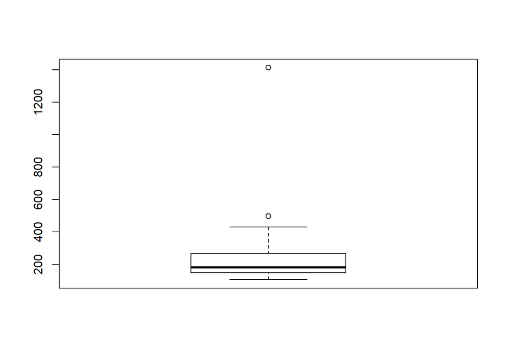

```r
#2016년등 전년도에 발생한 범죄를 2017년도에 검거하여 검거횟수가 발생횟수를 넘을 수는 있지만 종로구의 강간은 검거횟수가 발생횟수의 5배가까이 되어 정상적인 수치라 보기 어렵다.
#송파구 강도검거 횟수가 발생횟수의 3배에 달하나 발생 1회 검거 3회로 충분히 가능하다 판단되어 수정하지 않았다.
boxplot(df$강간강제추행.1)
```

```r
df$강간강제추행.1 <- ifelse(df$강간강제추행.1>500,mean(df$강간강제추행.1),df$강간강제추행.1)
```

### 방범용 cctv 많은곳 범죄 적은 곳

```r
dfa1 <- df%>%
  arrange(범죄발생)%>%
  head(10)
dfa1
```

```
##      자치구 전체cctv 방범용cctv 도시공원..놀이터 어린이.보호
## 1    도봉구      825        260               89          89
## 2    성동구     1327        663               56         305
## 3  서대문구     1254        603              230         129
## 4    금천구     1348        676              119         188
## 5    동작구     1302        693               88         291
## 6    강북구      831        469               86         108
## 7    성북구     1651        974               72         320
## 8    양천구     2482       1216               77         722
## 9    은평구     2108       1147              196         527
## 10 동대문구     1870        948               71         247
##    쓰레기.무단투기 기타 기간 범죄발생 범죄검거 살인 살인.1 강도 강도.1
## 1               47  340 2017     1999     1652    1      1    3      3
## 2               38  265 2017     2767     2031    1      1    3      3
## 3                0  292 2017     3113     2299    4      4    1      2
```

[output cut: 18 more lines]

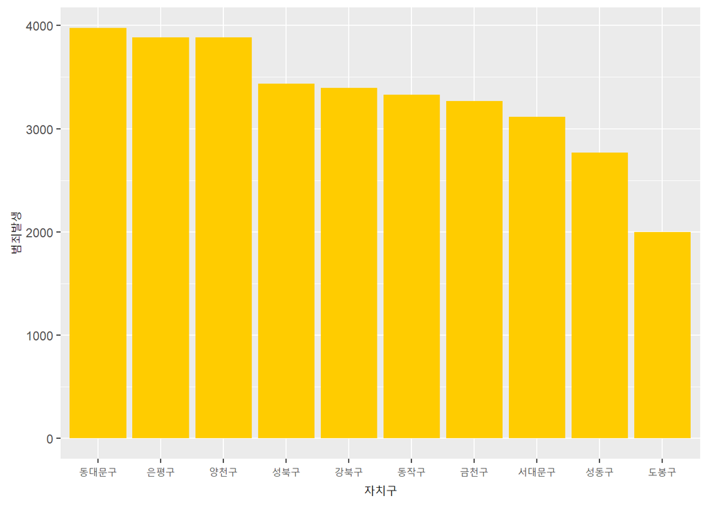

```r
ggplot(data = dfa1,aes(x=reorder(자치구,-범죄발생),y=범죄발생))+geom_col(fill="#FFCC00")+labs(x="자치구")
```

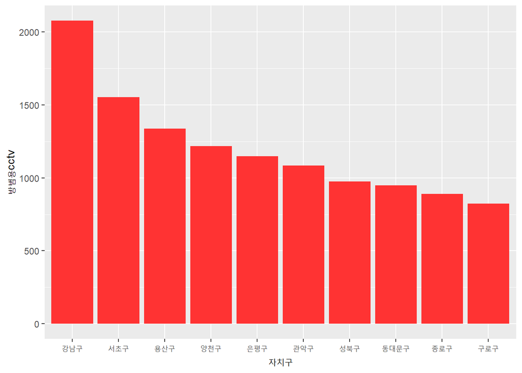

```r
dfa2 <-
df%>%
  arrange(desc(방범용cctv))%>%
  head(10)

ggplot(data = dfa2,aes(x=reorder(자치구,-방범용cctv),y=방범용cctv))+geom_col(fill="#FF3333")+labs(x="자치구")
```

### 교집합을 보여주는 intersect함수 사용

```r
intersect(df%>%
            arrange(범죄발생)%>%
            head(10),df%>%
            arrange(desc(방범용cctv))%>%
            head(10))
```

```
##     자치구 전체cctv 방범용cctv 도시공원..놀이터 어린이.보호
## 1   양천구     2482       1216               77         722
## 2   은평구     2108       1147              196         527
## 3   성북구     1651        974               72         320
## 4 동대문구     1870        948               71         247
##   쓰레기.무단투기 기타 기간 범죄발생 범죄검거 살인 살인.1 강도 강도.1
## 1              19  448 2017     3882     2660    3      2    3      2
## 2               3  235 2017     3883     3207    6      6    4      4
## 3              98  187 2017     3434     2479    7      7    8      8
## 4              28  576 2017     3975     3274   11     10    3      5
##   강간강제추행 강간강제추행.1 절도 절도.1 폭력 폭력.1
## 1          138            122 1590    756 2148   1778
## 2          230            213 1387    934 2256   2050
## 3          173            134 1344    703 1902   1627
## 4          165            149 1547   1017 2249   2093
```

```r
dfaa <- ggplot()+
  geom_col(data = dfa1,aes(x=reorder(자치구,-범죄발생),y=범죄발생,fill=자치구))
```

### 빨간 표시 된곳이 교집합을 통해 나온 겹치는 곳

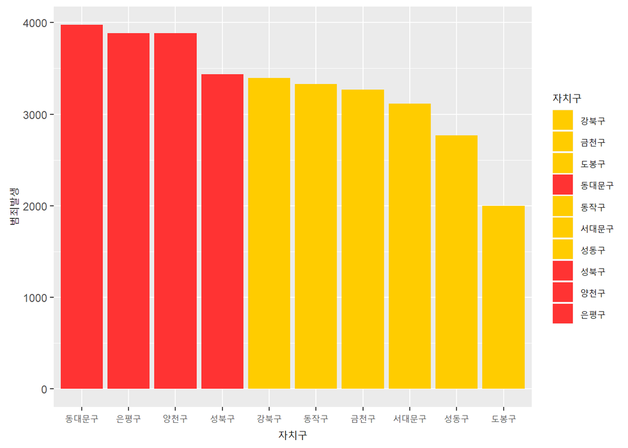

```r
dfaa+scale_fill_manual(values = c("#FFCC00","#FFCC00","#FFCC00","#FF3333","#FFCC00","#FFCC00","#FFCC00","#FF3333","#FF3333","#FF3333"))+labs(x="자치구")
```

-방범cctv 많은곳 범죄 발생 적은곳 상위 10곳중 동대문구, 성북구, 은평구, 양천구 4곳 동일

### 방범 외 목적의 CCTV들도 범죄예방에 도움이 되는지 알아보자

```r
dfb <- df%>%
  arrange(범죄발생)%>%
  head(10)
dfb
```

```
##      자치구 전체cctv 방범용cctv 도시공원..놀이터 어린이.보호
## 1    도봉구      825        260               89          89
## 2    성동구     1327        663               56         305
## 3  서대문구     1254        603              230         129
## 4    금천구     1348        676              119         188
## 5    동작구     1302        693               88         291
## 6    강북구      831        469               86         108
## 7    성북구     1651        974               72         320
## 8    양천구     2482       1216               77         722
## 9    은평구     2108       1147              196         527
## 10 동대문구     1870        948               71         247
##    쓰레기.무단투기 기타 기간 범죄발생 범죄검거 살인 살인.1 강도 강도.1
## 1               47  340 2017     1999     1652    1      1    3      3
## 2               38  265 2017     2767     2031    1      1    3      3
## 3                0  292 2017     3113     2299    4      4    1      2
```

[output cut: 18 more lines]

```r
df%>%
  arrange(desc(전체cctv))%>%
  head(10)
```

```
##      자치구 전체cctv 방범용cctv 도시공원..놀이터 어린이.보호
## 1    강남구     3238       2076              261         443
## 2    양천구     2482       1216               77         722
## 3    서초구     2297       1552               62         316
## 4    관악구     2109       1083              161         195
## 5    은평구     2108       1147              196         527
## 6    용산구     2096       1336              113         168
## 7    구로구     1884        823              294         415
## 8  동대문구     1870        948               71         247
## 9    성북구     1651        974               72         320
## 10   종로구     1619        891               73          38
##    쓰레기.무단투기 기타 기간 범죄발생 범죄검거 살인 살인.1 강도 강도.1
## 1                0  458 2017     7720     5321    7      7   20     24
## 2               19  448 2017     3882     2660    3      2    3      2
## 3                0  367 2017     4708     3237    9     10   13      7
```

[output cut: 18 more lines]

```r
df111 <- intersect(df%>%
            arrange(범죄발생)%>%
            head(10),df%>%
            arrange(desc(전체cctv))%>%
            head(10))
df111
```

```
##     자치구 전체cctv 방범용cctv 도시공원..놀이터 어린이.보호
## 1   양천구     2482       1216               77         722
## 2   은평구     2108       1147              196         527
## 3 동대문구     1870        948               71         247
## 4   성북구     1651        974               72         320
##   쓰레기.무단투기 기타 기간 범죄발생 범죄검거 살인 살인.1 강도 강도.1
## 1              19  448 2017     3882     2660    3      2    3      2
## 2               3  235 2017     3883     3207    6      6    4      4
## 3              28  576 2017     3975     3274   11     10    3      5
## 4              98  187 2017     3434     2479    7      7    8      8
##   강간강제추행 강간강제추행.1 절도 절도.1 폭력 폭력.1
## 1          138            122 1590    756 2148   1778
## 2          230            213 1387    934 2256   2050
## 3          165            149 1547   1017 2249   2093
## 4          173            134 1344    703 1902   1627
```

[figure not shown]

```r
dfb1 <- ggplot()+
  geom_col(data = dfb,aes(x=reorder(자치구,-범죄발생),y=범죄발생,fill=자치구))
dfb1+scale_fill_manual(values = c("#FFCC00","#FFCC00","#FFCC00","#FFCC00","#FF3333","#FFCC00","#FFCC00","#FF3333","#FF3333","#FF3333"))+labs(x="자치구")
```

-cctv많은곳 범죄발생 적은곳 상위 10곳중 동대문구,성북구,은평구,양천구 4곳 동일

-분석결과 방범용 CCTV와 전체 CCTV의 비교 결과가 같다.

## 전체CCTV를 사용한 관측치

```r
dfc <- df%>%
  arrange(desc(범죄발생))%>%
  head(10)

df%>%
  arrange(전체cctv)%>%
  head(10)
```

```
##      자치구 전체cctv 방범용cctv 도시공원..놀이터 어린이.보호
## 1    도봉구      825        260               89          89
## 2    강북구      831        469               86         108
## 3    광진구      878        376               51         208
## 4    강서구      911        623               51         182
## 5    중랑구      916        532               74          54
## 6    마포구      980        387               86         101
## 7    강동구     1010        537               84         125
## 8      중구     1023        495               96          20
## 9    송파구     1081        331              139         129
## 10 서대문구     1254        603              230         129
##    쓰레기.무단투기 기타 기간 범죄발생 범죄검거 살인 살인.1 강도 강도.1
## 1               47  340 2017     1999     1652    1      1    3      3
## 2               85   83 2017     3393     2824    8      8    7      5
## 3               72  171 2017     4646     3289    6      5   13      8
```

[output cut: 18 more lines]

```r
intersect(df%>%
            arrange(desc(범죄발생))%>%
            head(10),df%>%
            arrange(전체cctv)%>%
            head(10))
```

```
##   자치구 전체cctv 방범용cctv 도시공원..놀이터 어린이.보호 쓰레기.무단투기
## 1 광진구      878        376               51         208              72
## 2 강서구      911        623               51         182              28
## 3 중랑구      916        532               74          54               0
## 4 마포구      980        387               86         101               0
## 5 송파구     1081        331              139         129              19
##   기타 기간 범죄발생 범죄검거 살인 살인.1 강도 강도.1 강간강제추행
## 1  171 2017     4646     3289    6      5   13      8          261
## 2   27 2017     5135     3927   11     11    4      6          316
## 3  256 2017     4571     3392    5      5    3      4          172
## 4  406 2017     5278     3499    3      3    8      8          500
## 5  463 2017     5576     3870    6      6    1      3          288
##   강간강제추행.1 절도 절도.1 폭력 폭력.1
## 1            208 2220   1168 2146   1900
## 2            253 1888   1113 2916   2544
## 3            144 1533    813 2858   2426
## 4            429 2094    837 2673   2222
## 5            242 2274   1026 3007   2593
```

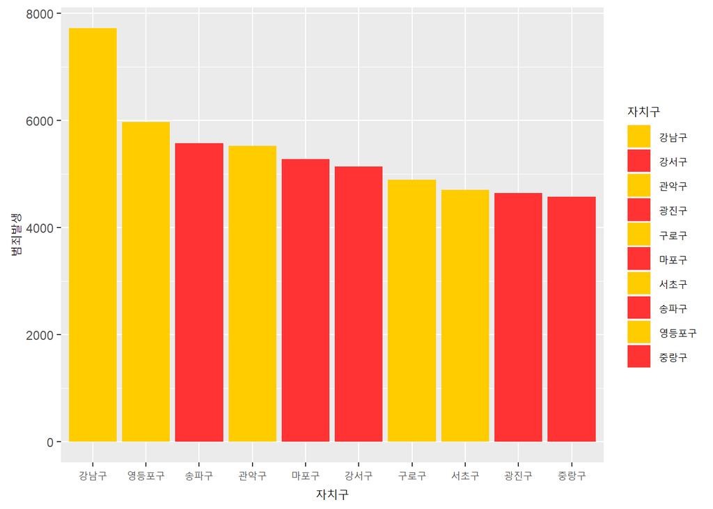

```r
dfc1 <- ggplot()+
  geom_col(data = dfc,aes(x=reorder(자치구,-범죄발생),y=범죄발생,fill=자치구))
dfc1+scale_fill_manual(values = c("#FFCC00","#FF3333","#FFCC00","#FF3333","#FFCC00","#FF3333","#FFCC00","#FF3333","#FFCC00","#FF3333"))+labs(x="자치구")
```

-cctv적은곳 범죄발생 많은곳 중 중랑구, 광진구, 강서구,마포구,송파구 5곳 동일

-cctv가 많고 범죄 발생이 적은곳, cctv가 적고 범죄 발생이 많은 곳은 상위 10개 지역중 4~5지역이 동일 했다.

## 검증하기: cctv가 적고 범죄 발생이 적은곳, cctv가 많고 범죄 발생이 많은 곳 살펴보기.

```r
dfd <- df%>%
  arrange(범죄발생)%>%
  head(10)

df%>%
  arrange(전체cctv)%>%
  head(10)
```

```
##      자치구 전체cctv 방범용cctv 도시공원..놀이터 어린이.보호
## 1    도봉구      825        260               89          89
## 2    강북구      831        469               86         108
## 3    광진구      878        376               51         208
## 4    강서구      911        623               51         182
## 5    중랑구      916        532               74          54
## 6    마포구      980        387               86         101
## 7    강동구     1010        537               84         125
## 8      중구     1023        495               96          20
## 9    송파구     1081        331              139         129
## 10 서대문구     1254        603              230         129
##    쓰레기.무단투기 기타 기간 범죄발생 범죄검거 살인 살인.1 강도 강도.1
## 1               47  340 2017     1999     1652    1      1    3      3
## 2               85   83 2017     3393     2824    8      8    7      5
## 3               72  171 2017     4646     3289    6      5   13      8
```

[output cut: 18 more lines]

```r
intersect(df%>%
            arrange(범죄발생)%>%
            head(10),df%>%
            arrange(전체cctv)%>%
            head(10))
```

```
##     자치구 전체cctv 방범용cctv 도시공원..놀이터 어린이.보호
## 1   도봉구      825        260               89          89
## 2   강북구      831        469               86         108
## 3 서대문구     1254        603              230         129
##   쓰레기.무단투기 기타 기간 범죄발생 범죄검거 살인 살인.1 강도 강도.1
## 1              47  340 2017     1999     1652    1      1    3      3
## 2              85   83 2017     3393     2824    8      8    7      5
## 3               0  292 2017     3113     2299    4      4    1      2
##   강간강제추행 강간강제추행.1 절도 절도.1 폭력 폭력.1
## 1          104            115  633    417 1258   1116
## 2          208            153 1014    635 2156   2023
## 3          202            181 1230    719 1676   1393
```

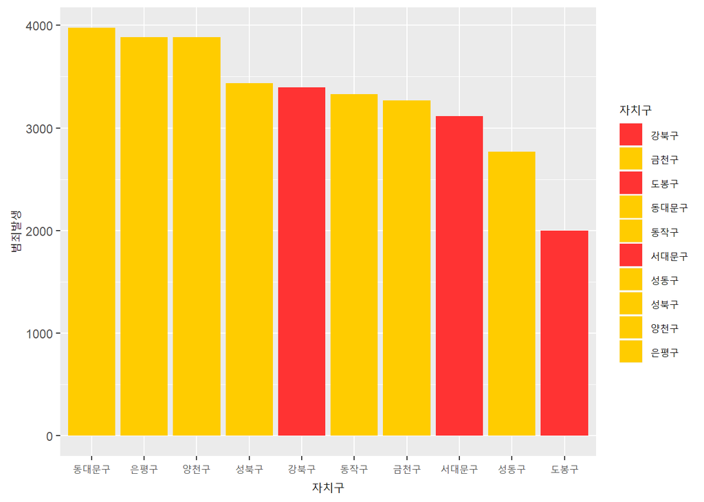

```r
dfd1 <- ggplot()+
  geom_col(data = dfd,aes(x=reorder(자치구,-범죄발생),y=범죄발생,fill=자치구))
dfd1+scale_fill_manual(values = c("#FF3333","#FFCC00","#FF3333","#FFCC00","#FFCC00","#FF3333","#FFCC00","#FFCC00","#FFCC00","#FFCC00"))+labs(x="자치구")
```

-cctv 적은곳 범죄발생 적은곳 중 서대문구, 도봉구,강북구 3곳 동일

```r
dfe <- df%>%
  arrange(desc(범죄발생))%>%
  head(10)

df%>%
  arrange(desc(전체cctv))%>%
  head(10)
```

```
##      자치구 전체cctv 방범용cctv 도시공원..놀이터 어린이.보호
## 1    강남구     3238       2076              261         443
## 2    양천구     2482       1216               77         722
## 3    서초구     2297       1552               62         316
## 4    관악구     2109       1083              161         195
## 5    은평구     2108       1147              196         527
## 6    용산구     2096       1336              113         168
## 7    구로구     1884        823              294         415
## 8  동대문구     1870        948               71         247
## 9    성북구     1651        974               72         320
## 10   종로구     1619        891               73          38
##    쓰레기.무단투기 기타 기간 범죄발생 범죄검거 살인 살인.1 강도 강도.1
## 1                0  458 2017     7720     5321    7      7   20     24
## 2               19  448 2017     3882     2660    3      2    3      2
## 3                0  367 2017     4708     3237    9     10   13      7
```

[output cut: 18 more lines]

```r
intersect(df%>%
            arrange(desc(범죄발생))%>%
            head(10),df%>%
            arrange(desc(전체cctv))%>%
            head(10))
```

```
##   자치구 전체cctv 방범용cctv 도시공원..놀이터 어린이.보호 쓰레기.무단투기
## 1 강남구     3238       2076              261         443               0
## 2 서초구     2297       1552               62         316               0
## 3 관악구     2109       1083              161         195              57
## 4 구로구     1884        823              294         415              29
##   기타 기간 범죄발생 범죄검거 살인 살인.1 강도 강도.1 강간강제추행
## 1  458 2017     7720     5321    7      7   20     24          607
## 2  367 2017     4708     3237    9     10   13      7          470
## 3  613 2017     5525     4154    8      7    7      6          379
## 4  323 2017     4895     3408    7      8    8      6          328
##   강간강제추행.1 절도 절도.1 폭력 폭력.1
## 1            496 3130   1383 3956   3411
## 2            283 1812    835 2404   2102
## 3            323 1979   1152 3152   2666
## 4            181 1725    869 2827   2344
```

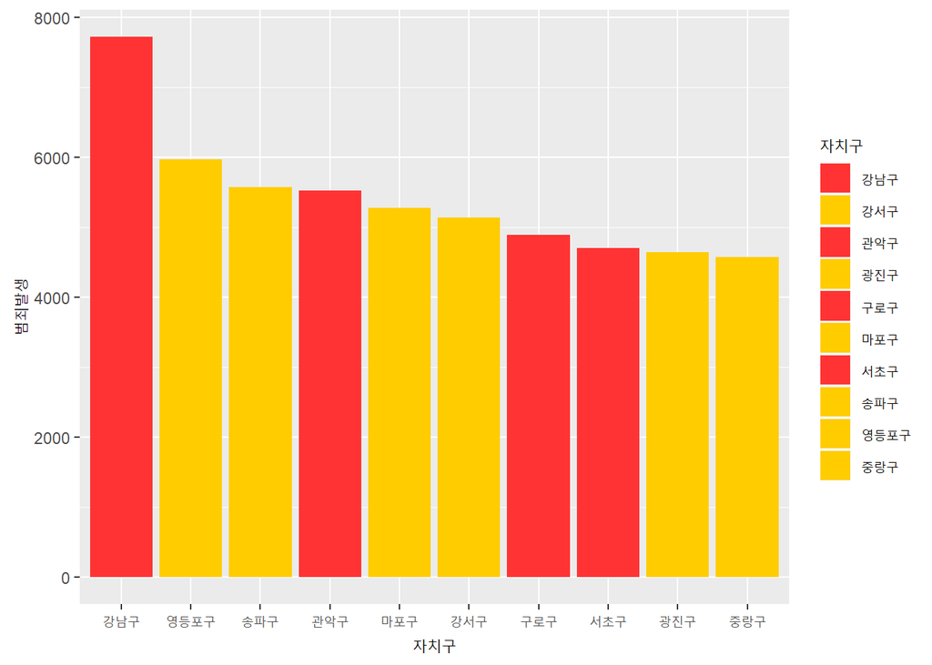

```r
dfe1 <- ggplot()+
  geom_col(data = dfe,aes(x=reorder(자치구,-범죄발생),y=범죄발생,fill=자치구))
dfe1+scale_fill_manual(values = c("#FF3333","#FFCC00","#FF3333","#FFCC00","#FF3333","#FFCC00","#FF3333","#FFCC00","#FFCC00","#FFCC00"))+labs(x="자치구")
```

-CCTV많은곳 범죄발생 많은곳 강남구,관악구,구로구,서초구 4곳

-강남역은 유동인구가 많고 유흥가가 많은 특성상 범죄발생 빈도와 CCTV댓수 두가지 모두 많은 특수한 지역이라 제외하여 3곳

### cctv가 적고 범죄 발생 적은곳과 cctv가 많고 범죄 발생이 많은 곳은 상위 10개지역중 3곳이 동일하게 나왔다.

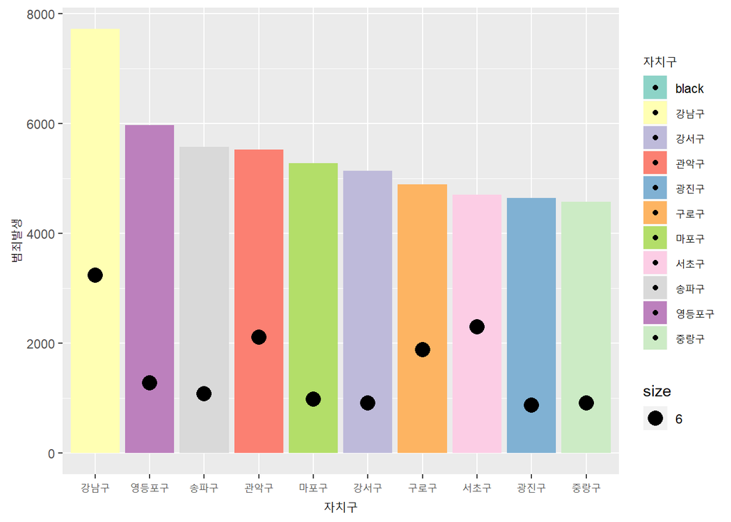

```r
#CCTV가 적고 범죄율 높은 지역을 같이 나타낸 그래프. 막대가 범죄발생 점이 CCTV
ggplot()+
geom_col(data = dfc,aes(x=reorder(자치구,-범죄발생),y=범죄발생,fill=자치구))+scale_fill_brewer(palette = "Set3")+
  geom_point(data=dfc,aes(x=자치구,y=전체cctv,fill="black",size=6))+labs(x="자치구")
```

## 검거율

```r
library(RColorBrewer)
library(tidyr)
library(reshape)
df<- df%>%
  mutate(검거율=df$범죄검거/df$범죄발생*100)

df11<- df%>%
  select(자치구,전체cctv,검거율)%>%
  arrange(desc(검거율))
df11
```

```
##      자치구 전체cctv    검거율
## 1    종로구     1619 109.36653
## 2    강북구      831  83.23018
## 3    도봉구      825  82.64132
## 4    은평구     2108  82.59078
## 5  동대문구     1870  82.36478
## 6    금천구     1348  78.77489
## 7    강서구      911  76.47517
## 8    강동구     1010  76.15583
## 9    관악구     2109  75.18552
## 10   중랑구      916  74.20696
## 11 서대문구     1254  73.85159
## 12   성동구     1327  73.40080
## 13   노원구     1566  72.39249
## 14   용산구     2096  72.31527
## 15   성북구     1651  72.18987
## 16   광진구      878  70.79208
## 17   구로구     1884  69.62206
## 18   송파구     1081  69.40459
## 19   강남구     3238  68.92487
## 20   서초구     2297  68.75531
## 21   양천구     2482  68.52138
## 22     중구     1023  68.14054
## 23   동작구     1302  67.32733
## 24 영등포구     1277  67.21394
## 25   마포구      980  66.29405
```

```r
df22 <- intersect(df%>%
            arrange(desc(검거율))%>%
            head(10),df%>%
            arrange(desc(전체cctv))%>%
            head(10))

df22
```

```
##     자치구 전체cctv 방범용cctv 도시공원..놀이터 어린이.보호
## 1   관악구     2109       1083              161         195
## 2   은평구     2108       1147              196         527
## 3 동대문구     1870        948               71         247
## 4   종로구     1619        891               73          38
##   쓰레기.무단투기 기타 기간 범죄발생 범죄검거 살인 살인.1 강도 강도.1
## 1              57  613 2017     5525     4154    8      7    7      6
## 2               3  235 2017     3883     3207    6      6    4      4
## 3              28  576 2017     3975     3274   11     10    3      5
## 4               0  617 2017     4057     4437    7      9   10     15
##   강간강제추행 강간강제추행.1 절도 절도.1 폭력 폭력.1    검거율
## 1          379         323.00 1979   1152 3152   2666  75.18552
## 2          230         213.00 1387    934 2256   2050  82.59078
## 3          165         149.00 1547   1017 2249   2093  82.36478
## 4          253         262.32 1644    905 2143   2096 109.36653
```

-상위 10곳중 관악,은평,동대문,종로 4곳이 동일

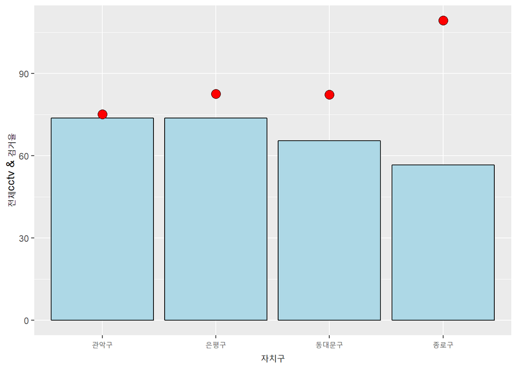

```r
g0 <- ggplot()+
  geom_col(data=df22,aes(x=reorder(자치구,-전체cctv),y=전체cctv*0.035),fill="lightblue",colour="black")
g0+
  geom_point(data=df22,aes(x=자치구,y=검거율),fill="red",size = 4, shape = 21)+labs(x="자치구",y="전체cctv & 검거율")
```

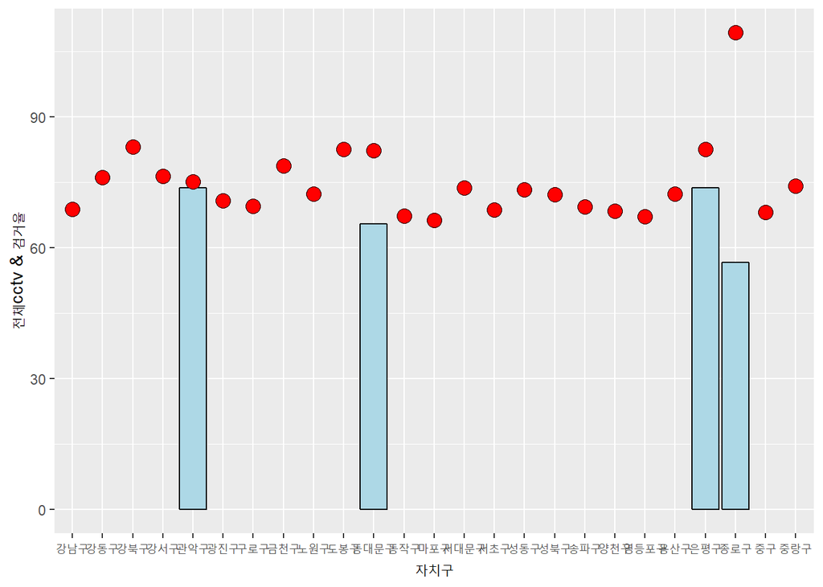

```r
g1 <- ggplot()+
  geom_col(data=df22,aes(x=reorder(자치구,-전체cctv),y=전체cctv*0.035),fill="lightblue",colour="black")
g1+
  geom_point(data=df,aes(x=자치구,y=검거율),fill="red",size = 4, shape = 21)+labs(x="자치구",y="전체cctv & 검거율")
```

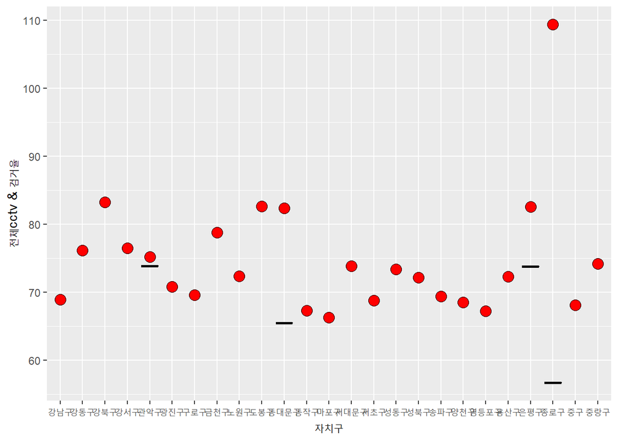

```r
g2 <- ggplot()+
  geom_boxplot(data=df22,aes(x=reorder(자치구,-전체cctv),y=전체cctv*0.035),fill="lightblue",colour="black")
g2+
  geom_point(data=df11,aes(x=자치구,y=검거율),fill="red",size = 4, shape = 21)+labs(x="자치구",y="전체cctv & 검거율")
```

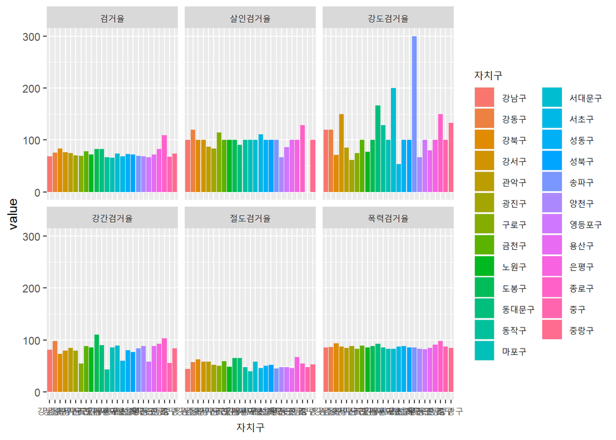

```r
df<- df%>%
  mutate(살인검거율=df$살인.1/df$살인*100,
              강도검거율=df$강도.1/df$강도*100,
              강간검거율=df$강간강제추행.1/df$강간강제추행*100,
              절도검거율=df$절도.1/df$절도*100,
              폭력검거율=df$폭력.1/df$폭력*100)
dff <- df%>%
  select(자치구,전체cctv,검거율,살인검거율,강도검거율,강간검거율,절도검거율,폭력검거율)

dff1 <- melt(dff,measure.=c(3:8))
ggplot(dff1,aes(x=자치구,y=value,fill=자치구))+geom_col()+facet_wrap(variable~.)
```